[figure not shown]

# Grado de Ciencia de Datos.

## Práctica 1. Normalización, codificación y selección de características.

Detalles en: https://scikit-learn.org/stable/modules/preprocessing.html

#### Andreu Cantó Belda y Amparo Gálvez Vilar

## 1.1. Vamos a normalizar variables

Leemos las librerias necesarias

```python
from sklearn import datasets
import matplotlib.pyplot as plt
%matplotlib inline
import numpy as np
import sklearn
```

### Descargamos los datos de los datasets de sklearn y los visualizamos un poco

```python
iris = datasets.load_iris()
```

```python
# Muestra la descripción
print(iris.DESCR)
```

```
.. _iris_dataset:

Iris plants dataset
--------------------

**Data Set Characteristics:**

    :Number of Instances: 150 (50 in each of three classes)
    :Number of Attributes: 4 numeric, predictive attributes and the class
    :Attribute Information:
        - sepal length in cm
        - sepal width in cm
        - petal length in cm
        - petal width in cm
        - class:
                - Iris-Setosa
                - Iris-Versicolour
                - Iris-Virginica

    :Summary Statistics:

    ============== ==== ==== ======= ===== ====================
                    Min  Max   Mean    SD   Class Correlation
    ============== ==== ==== ======= ===== ====================
    sepal length:   4.3  7.9   5.84   0.83    0.7826
    sepal width:    2.0  4.4   3.05   0.43   -0.4194
    petal length:   1.0  6.9   3.76   1.76    0.9490  (high!)
    petal width:    0.1  2.5   1.20   0.76    0.9565  (high!)
    ============== ==== ==== ======= ===== ====================

    :Missing Attribute Values: None
    :Class Distribution: 33.3% for each of 3 classes.
    :Creator: R.A. Fisher
    :Donor: Michael Marshall (MARSHALL%PLU@io.arc.nasa.gov)
    :Date: July, 1988

The famous Iris database, first used by Sir R.A. Fisher. The dataset is taken
from Fisher's paper. Note that it's the same as in R, but not as in the UCI
Machine Learning Repository, which has two wrong data points.

```

[output cut: 8 more lines]

```

   - Fisher, R.A. "The use of multiple measurements in taxonomic problems"
     Annual Eugenics, 7, Part II, 179-188 (1936); also in "Contributions to
     Mathematical Statistics" (John Wiley, NY, 1950).
   - Duda, R.O., & Hart, P.E. (1973) Pattern Classification and Scene Analysis.
     (Q327.D83) John Wiley & Sons.  ISBN 0-471-22361-1.  See page 218.
   - Dasarathy, B.V. (1980) "Nosing Around the Neighborhood: A New System
     Structure and Classification Rule for Recognition in Partially Exposed
     Environments".  IEEE Transactions on Pattern Analysis and Machine
     Intelligence, Vol. PAMI-2, No. 1, 67-71.
   - Gates, G.W. (1972) "The Reduced Nearest Neighbor Rule".  IEEE Transactions
     on Information Theory, May 1972, 431-433.
   - See also: 1988 MLC Proceedings, 54-64.  Cheeseman et al"s AUTOCLASS II
     conceptual clustering system finds 3 classes in the data.
   - Many, many more ...
```

```python
# las entradas
iris.data
```

```
array([[5.1, 3.5, 1.4, 0.2],
       [4.9, 3. , 1.4, 0.2],
       [4.7, 3.2, 1.3, 0.2],
       [4.6, 3.1, 1.5, 0.2],
       [5. , 3.6, 1.4, 0.2],
       [5.4, 3.9, 1.7, 0.4],
       [4.6, 3.4, 1.4, 0.3],
       [5. , 3.4, 1.5, 0.2],
       [4.4, 2.9, 1.4, 0.2],
       [4.9, 3.1, 1.5, 0.1],
       [5.4, 3.7, 1.5, 0.2],
       [4.8, 3.4, 1.6, 0.2],
       [4.8, 3. , 1.4, 0.1],
       [4.3, 3. , 1.1, 0.1],
       [5.8, 4. , 1.2, 0.2],
       [5.7, 4.4, 1.5, 0.4],
       [5.4, 3.9, 1.3, 0.4],
       [5.1, 3.5, 1.4, 0.3],
       [5.7, 3.8, 1.7, 0.3],
       [5.1, 3.8, 1.5, 0.3],
       [5.4, 3.4, 1.7, 0.2],
       [5.1, 3.7, 1.5, 0.4],
       [4.6, 3.6, 1. , 0.2],
       [5.1, 3.3, 1.7, 0.5],
       [4.8, 3.4, 1.9, 0.2],
       [5. , 3. , 1.6, 0.2],
       [5. , 3.4, 1.6, 0.4],
       [5.2, 3.5, 1.5, 0.2],
       [5.2, 3.4, 1.4, 0.2],
       [4.7, 3.2, 1.6, 0.2],
       [4.8, 3.1, 1.6, 0.2],
       [5.4, 3.4, 1.5, 0.4],
       [5.2, 4.1, 1.5, 0.1],
       [5.5, 4.2, 1.4, 0.2],
       [4.9, 3.1, 1.5, 0.2],
       [5. , 3.2, 1.2, 0.2],
       [5.5, 3.5, 1.3, 0.2],
       [4.9, 3.6, 1.4, 0.1],
       [4.4, 3. , 1.3, 0.2],
       [5.1, 3.4, 1.5, 0.2],
```

[output cut: 95 more lines]

```
       [7.7, 3. , 6.1, 2.3],
       [6.3, 3.4, 5.6, 2.4],
       [6.4, 3.1, 5.5, 1.8],
       [6. , 3. , 4.8, 1.8],
       [6.9, 3.1, 5.4, 2.1],
       [6.7, 3.1, 5.6, 2.4],
       [6.9, 3.1, 5.1, 2.3],
       [5.8, 2.7, 5.1, 1.9],
       [6.8, 3.2, 5.9, 2.3],
       [6.7, 3.3, 5.7, 2.5],
       [6.7, 3. , 5.2, 2.3],
       [6.3, 2.5, 5. , 1.9],
       [6.5, 3. , 5.2, 2. ],
       [6.2, 3.4, 5.4, 2.3],
       [5.9, 3. , 5.1, 1.8]])
```

```python
# las salidas
iris.target
```

```
array([0, 0, 0, 0, 0, 0, 0, 0, 0, 0, 0, 0, 0, 0, 0, 0, 0, 0, 0, 0, 0, 0,
       0, 0, 0, 0, 0, 0, 0, 0, 0, 0, 0, 0, 0, 0, 0, 0, 0, 0, 0, 0, 0, 0,
       0, 0, 0, 0, 0, 0, 1, 1, 1, 1, 1, 1, 1, 1, 1, 1, 1, 1, 1, 1, 1, 1,
       1, 1, 1, 1, 1, 1, 1, 1, 1, 1, 1, 1, 1, 1, 1, 1, 1, 1, 1, 1, 1, 1,
       1, 1, 1, 1, 1, 1, 1, 1, 1, 1, 1, 1, 2, 2, 2, 2, 2, 2, 2, 2, 2, 2,
       2, 2, 2, 2, 2, 2, 2, 2, 2, 2, 2, 2, 2, 2, 2, 2, 2, 2, 2, 2, 2, 2,
       2, 2, 2, 2, 2, 2, 2, 2, 2, 2, 2, 2, 2, 2, 2, 2, 2, 2])
```

```python
# tamaño de entrada
iris.data.shape
```

```
(150, 4)
```

```python
# tamaño de salida
iris.target.shape
```

```
(150,)
```

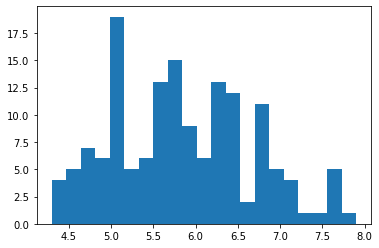

```python
# un histograma de la primera dimension
plt.hist(iris.data[:,0],21);
```

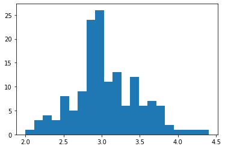

```python
# un histograma de la segunda dimension
plt.hist(iris.data[:,1],21);
```

### Normalizamos la primera variable "a mano"

```python
X = iris.data
```

#### Normalizamos sin quitar el mínimo

```python
X_n = X[:,0] / np.max(X[:,0])
```

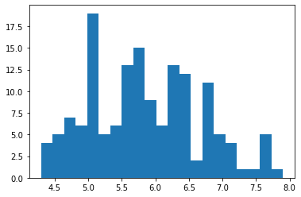

```python
# Histograma sin normalizar
plt.hist(X[:,0],21);
```

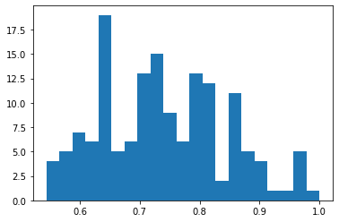

```python
# Histograma normalizando
plt.hist(X_n,21);
```

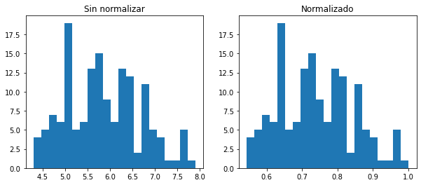

```python
# Usando subplot ...
plt.figure(figsize=(10,4))
plt.subplot(1,2,1), plt.hist(X[:,0],21), plt.title('Sin normalizar')
plt.subplot(1,2,2), plt.hist(X_n,21), plt.title('Normalizado');
```

#### Ejercicio:

Haz lo mismo pero para la dimensión 2, i.e. X[:,1]

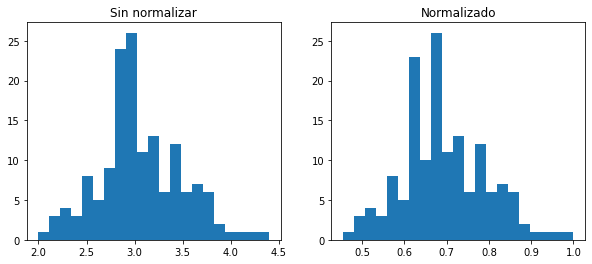

```python
X_n2 = X[:,1] / np.max(X[:,1])
plt.figure(figsize=(10,4))
plt.subplot(1,2,1), plt.hist(X[:,1],21), plt.title('Sin normalizar')
plt.subplot(1,2,2), plt.hist(X_n2,21), plt.title('Normalizado');
```

#### Normalizamos quitando el mínimo

```python
X_n = (X[:,0] - np.min(X[:,0])) / (np.max(X[:,0]) - np.min(X[:,0]))
```

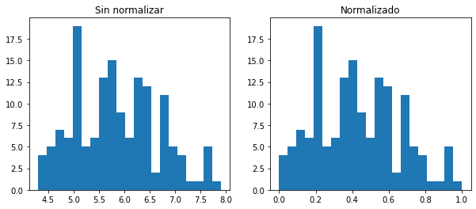

```python
plt.figure(figsize=(10,4))
plt.subplot(1,2,1), plt.hist(X[:,0],21), plt.title('Sin normalizar')
plt.subplot(1,2,2), plt.hist(X_n,21), plt.title('Normalizado');
```

#### Ejercicio:

Haz lo mismo pero para la dimensión 2, i.e. X[:,1]

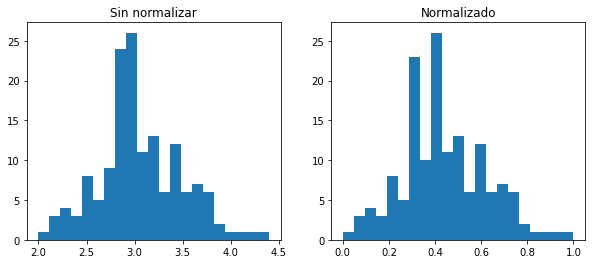

```python
X_n2 = (X[:,1] - np.min(X[:,1])) / (np.max(X[:,1]) - np.min(X[:,1]))
plt.figure(figsize=(10,4))
plt.subplot(1,2,1), plt.hist(X[:,1],21), plt.title('Sin normalizar')
plt.subplot(1,2,2), plt.hist(X_n2,21), plt.title('Normalizado');
```

#### Estandarizamos

```python
X_n = (X[:,0] - np.mean(X[:,0])) / (np.std(X[:,0]))
```

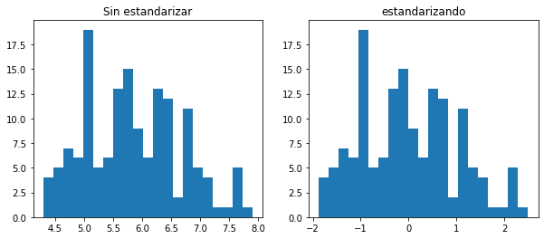

```python
plt.figure(figsize=(10,4))
plt.subplot(1,2,1), plt.hist(X[:,0],21), plt.title('Sin estandarizar')
plt.subplot(1,2,2), plt.hist(X_n,21), plt.title('estandarizando');
```

#### Ejercicio:

Haz lo mismo pero para la dimensión 2, i.e. X[:,1]

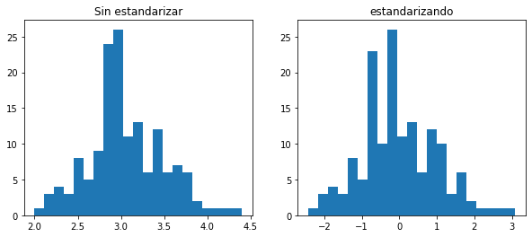

```python
X_n2 = (X[:,1] - np.mean(X[:,1])) / (np.std(X[:,1]))
plt.figure(figsize=(10,4))
plt.subplot(1,2,1), plt.hist(X[:,1],21), plt.title('Sin estandarizar')
plt.subplot(1,2,2), plt.hist(X_n2,21), plt.title('estandarizando');
```

#### Ejercicio:

Explica la diferencia entre los tres métodos

Cuando normalizamos sin quitar el minimo el rango de valores no empieza en cero sino que empieza desde el mínimo valor entre el máximo.

Al normalizar quitando el mínimo el rango de valores que se obtiene si que va de cero a uno.

Por último, al estandarizar se obtiene un rango de valores centrado en cero con desviación estandar 1.

### Normalizamos usando Sklearn

https://scikit-learn.org/stable/modules/preprocessing.html

```python
from sklearn import preprocessing
```

#### Estandarizamos directamente

```python
# Usamos la función de estandarización del sklearn
X_n = preprocessing.scale(X[:,0])
```

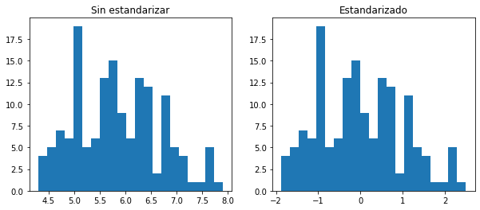

```python
plt.figure(figsize=(10,4))
plt.subplot(1,2,1), plt.hist(X[:,0],21), plt.title('Sin estandarizar')
plt.subplot(1,2,2), plt.hist(X_n,21), plt.title('Estandarizado');
```

#### Usamos los modelos de normalizacion

```python
X[:,0].shape
```

```
(150,)
```

```python
# creamos la funcion para estandarizar y la entrenamos
scaler = preprocessing.StandardScaler().fit(X)
```

```python
# La funcion contiene informacion sobre los datos originales

# la media
print(scaler.mean_)

# el rango
print(scaler.scale_)
```

```
[5.84333333 3.05733333 3.758      1.19933333]
[0.82530129 0.43441097 1.75940407 0.75969263]
```

```python
# si quiero estandarizar solo tengo que aplicar la funcion a los datos que quiera estandarizar
X_n = scaler.transform(X)
```

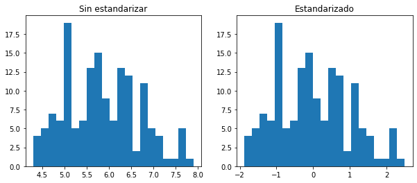

```python
#Visualizamos el standarizado de la primera dimensión

plt.figure(figsize=(10,4))
plt.subplot(1,2,1), plt.hist(X[:,0],21), plt.title('Sin estandarizar')
plt.subplot(1,2,2), plt.hist(X_n[:,0],21), plt.title('Estandarizado');
```

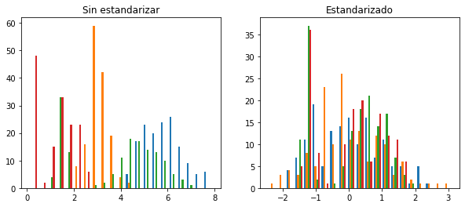

```python
# Fíjate que ha estandarizado todas las dimensiones
plt.figure(figsize=(10,4))
plt.subplot(1,2,1), plt.hist(X,21), plt.title('Sin estandarizar')
plt.subplot(1,2,2), plt.hist(X_n,21), plt.title('Estandarizado');
```

#### Ejercicio:

Hay otros modelos, pruébalos. ¿Qué es lo que hacen en los datos?

- `preprocessing.MinMaxScaler()`
- `preprocessing.MaxAbsScaler()`

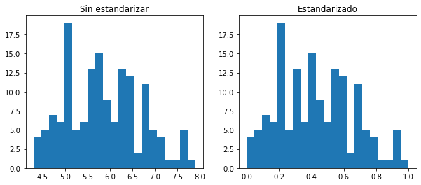

```python
minmax = preprocessing.MinMaxScaler().fit(X)

X_n = minmax.transform(X)

plt.figure(figsize=(10,4))
plt.subplot(1,2,1), plt.hist(X[:,0],21), plt.title('Sin estandarizar')
plt.subplot(1,2,2), plt.hist(X_n[:,0],21), plt.title('Estandarizado');
```

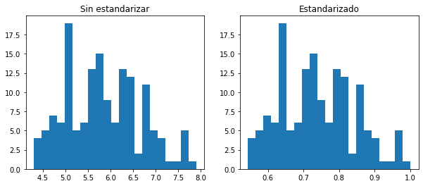

```python
maxabs = preprocessing.MaxAbsScaler().fit(X)

X_n = maxabs.transform(X)

plt.figure(figsize=(10,4))
plt.subplot(1,2,1), plt.hist(X[:,0],21), plt.title('Sin estandarizar')
plt.subplot(1,2,2), plt.hist(X_n[:,0],21), plt.title('Estandarizado');
```

La función MinMax normaliza los valores entre los dos valores introducidos, cero y uno por defecto.  
La función MaxAbs normaliza los valores entre -1 y 1.

#### Ejercicio:

El uso de modelos de normalización nos permite normalizar otros data sets utilizando exactamente la misma transformación. Esto es útil para normalizar los datos de entrenamiento, test y validación de la misma forma utilizando solo la información de los datos de entrenamiento.

Particiona los datos originales en train/test, entrena el modelo de normalización utilizando los datos de train, y normaliza los datos de train y test utilizando este modelo. Ayuda: utiliza la función `train_test_split` de sklearn.

```
(<AxesSubplot:title={'center':'Test Estandarizado'}>,
 (array([2., 0., 1., 7., 3., 1., 0., 0., 3., 2., 4., 2., 5., 1., 2., 3., 0.,
         1., 0., 0., 1.]),
  array([0.02777778, 0.07142857, 0.11507937, 0.15873016, 0.20238095,
         0.24603175, 0.28968254, 0.33333333, 0.37698413, 0.42063492,
         0.46428571, 0.50793651, 0.5515873 , 0.5952381 , 0.63888889,
         0.68253968, 0.72619048, 0.76984127, 0.81349206, 0.85714286,
         0.90079365, 0.94444444]),
  <BarContainer object of 21 artists>),
```

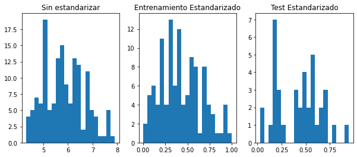

```python
# PARTICIÓN
from sklearn.model_selection import train_test_split
train, test = train_test_split(X)

# NORMALIZAR TRAIN Y TEST
train_st = preprocessing.MinMaxScaler().fit(train)

train_st_trans = train_st.transform(train)

test_st_trans = train_st.transform(test)


plt.figure(figsize=(10,4))
plt.subplot(1,3,1), plt.hist(X[:,0],21), plt.title('Sin estandarizar')
plt.subplot(1,3,2), plt.hist(train_st_trans[:,0],21), plt.title('Entrenamiento Estandarizado')
plt.subplot(1,3,3), plt.hist(test_st_trans[:,0],21), plt.title('Test Estandarizado')
```

## 1.2 Codificamos los datos

### Codificación ordinaria

Esta codificación hace corresponder a cada clase un número entero.

```python
from sklearn import preprocessing

enc = preprocessing.OrdinalEncoder()

X = [['Clase0'],['Clase_1'],['Clase_2']]

enc.fit(X)

enc.transform([['Clase_2']])
```

```
array([[2.]])
```

```python
# Se puede hacer con un vector de varias dimensiones
# Cada dimension tiene sus valores de codificacion correspondientes
enc2 = preprocessing.OrdinalEncoder()

# La primera lista será "1", la segunda "0"
X = [['male', 'from US', 'uses Safari'], ['female', 'from Europe', 'uses Firefox']]
enc2.fit(X)

enc2.transform([['female', 'from US','uses Safari']])
```

```
array([[0., 1., 1.]])
```

#### Ejercicio:

¿Qué pasa si cada dimensión tiene un número distinto de clases? Haz un ejemplo añadiendo más muestras a X.

No ocurre nada, cada una tendrá su propio rango.

```python
enc = preprocessing.OrdinalEncoder()

X = [['male', 'from US', 'uses Safari'], ['female', 'from Europe', 'uses Firefox'],
     ['male','from Asia', 'uses Chrome'], ['female','from Oceania', 'uses Safari']]

enc.fit(X)

enc.transform([['female', 'from US','uses Safari']])
```

```
array([[0., 3., 2.]])
```

### Codificación one-hot

Esta codificación convierte la salida en un vector de probabilidades para cada clase.

```python
enc = preprocessing.OneHotEncoder()

X = [['Clase 0'], ['Clase_1'], ['Clase_2']]
enc.fit(X)

enc.transform([['Clase_2']]).toarray()
```

```
array([[0., 0., 1.]])
```

#### Ejercicio:

¿Qué pasa si tenemos varias dimensiones?

```python
enc = preprocessing.OneHotEncoder()

X = [['male', 'from US', 'uses Safari'], ['female', 'from Europe', 'uses Firefox']]

enc.fit(X)

enc.transform([['female', 'from US','uses Safari']]).toarray()
```

```
array([[1., 0., 0., 1., 0., 1.]])
```

Cuando tenemos varias dimensiones las probabilidades se juntan en un array donde los n primeros elementos correpsonden con las n clases que tiene la primera dimesión y asi con las demás.

#### Se pueden especificar las categorias que existen, e incluso decir que hacer con las categorias que no están definidas

```python
enc = preprocessing.OneHotEncoder(handle_unknown='ignore')

X = [['Clase 0'],['Clase_1'],['Clase_2']]
enc.fit(X)

enc.transform([['Clase_3']]).toarray()
```

```
array([[0., 0., 0.]])
```

### Discretización de los datos

Si los datos son continuos o discretos pero los queremos convertir a categorías podemos discretizar. El proceso es similar al de la generación de histograma donde cada datos se le hace corresponder un *bin*, en este caso una clase.

```python
X = np.array([[ -3., 5., 15 ],
              [  0., 6., 14 ],
              [  6., 3., 11 ]])
est = preprocessing.KBinsDiscretizer(n_bins=[3, 2, 2], encode='ordinal').fit(X)
```

```python
est.transform(X)
```

```
array([[0., 1., 1.],
       [1., 1., 1.],
       [2., 0., 0.]])
```

#### Ejercicio:

Discretiza los datos de entrada de IRIS (los de arriba del todo) para que la primera variable tenga 2 categorías, la segunda 4 categorías, la tercera 10 categorías y la cuarta 5 categorías. Hazlo usando particiones de train y test y entrenando el discretizador con train y aplicandolo a train y a test.

```python
X = iris.data

train, test = train_test_split(X)

est = preprocessing.KBinsDiscretizer(n_bins=[2, 4, 10, 5], encode='ordinal').fit(train)
est.transform(test)
```

```
array([[1., 0., 7., 3.],
       [1., 1., 4., 2.],
       [1., 0., 9., 3.],
       [0., 2., 2., 1.],
       [0., 3., 1., 1.],
       [1., 2., 7., 3.],
       [1., 2., 4., 3.],
       [1., 2., 7., 3.],
       [0., 2., 4., 2.],
       [1., 0., 5., 3.],
       [0., 2., 2., 1.],
       [0., 3., 3., 1.],
       [0., 2., 0., 1.],
       [0., 2., 2., 1.],
       [1., 0., 7., 3.],
       [0., 3., 0., 1.],
       [1., 2., 8., 4.],
       [0., 3., 2., 1.],
       [0., 2., 1., 1.],
       [1., 1., 8., 4.],
       [1., 0., 7., 3.],
       [0., 0., 3., 2.],
       [0., 2., 0., 0.],
       [0., 0., 3., 1.],
       [1., 3., 9., 4.],
       [0., 3., 3., 1.],
       [1., 0., 7., 3.],
       [0., 3., 0., 1.],
       [1., 1., 9., 3.],
       [0., 3., 2., 1.],
       [1., 2., 8., 3.],
       [1., 2., 5., 2.],
       [1., 2., 7., 3.],
       [1., 2., 9., 4.],
       [0., 1., 1., 1.],
       [0., 2., 4., 2.],
       [1., 0., 5., 2.],
       [1., 2., 7., 4.]])
```

# 1.3 Selección de caraterísticas mediante métodos *filter*

## Correlación entre las variables de entrada y la de salida

El método consiste en ver qué variables de entrada están más correlacionadas con la salida y escoger aquellas con mayor correlación. Seguimos con el dataset IRIS

```python
X, y = datasets.load_iris(return_X_y=True)
```

#### Ejercicio:

Calcula la correlación (`np.corrcoef`) entre las entradas y la salidas. Muestra los valores calculados y selecciona dos de las variables más adecuadas.

```python
print(np.corrcoef(X[:,0],y))
print(np.corrcoef(X[:,1],y))
print(np.corrcoef(X[:,2],y))
print(np.corrcoef(X[:,3],y))
```

```
[[1.         0.78256123]
 [0.78256123 1.        ]]
[[ 1.         -0.42665756]
 [-0.42665756  1.        ]]
[[1.        0.9490347]
 [0.9490347 1.       ]]
[[1.         0.95654733]
 [0.95654733 1.        ]]
```

Las dos últimas variables son las que mayor correlación tiene, por tanto, las más adecuadas.

## Correlación entre variables de entrada

En este caso vamos a descartar variables de entrada que estén muy correlacionadas entre sí, puesto que entendemos que no añaden más información al modelo y pueden perjudicar su rendimiento. Por ejemplo si encontramos que las variables `X[:,0]` y `X[:,1]` (dimensiones 1 y 2) están muy correlacionadas descartaremos una de las dos.

#### Ejercicio:

Calcula la correlación entre todas las variables de entrada y descarta alguna con alta correlación cruzada.

```python
print(np.corrcoef(np.transpose(X)))
```

```
[[ 1.         -0.11756978  0.87175378  0.81794113]
 [-0.11756978  1.         -0.4284401  -0.36612593]
 [ 0.87175378 -0.4284401   1.          0.96286543]
 [ 0.81794113 -0.36612593  0.96286543  1.        ]]
```

Las variables 2 y 3 tienen gran correlacion entre ellas y entre la variable 0. Por tanto, podemos descartar dos de estas varaibles.

#### Ejercicio

Representa gráficamente las relaciones entre variables (puedes usar `plt.imshow`).

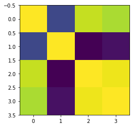

```python
plt.imshow(np.corrcoef(np.transpose(X)))
```

## Información mutua (MI) entre las variables de entrada y salida

En primer lugar vamos a calcular la MI. Por definición sabemos que la MI entre dos variables **discretas** $X,Y$ viene dada por $$ \textrm{MI}(X,Y) = \sum_{y\in \mathcal{Y}}\sum_{x\in \mathcal{X}} p(x,y)\log\left(\frac{p(x,y)}{p(x)p(y)}\right) $$ Más info: https://en.wikipedia.org/wiki/Mutual_information

En primer lugar estimamos la probabilidad para cada clase de la variable de salida. También podemos calcular su entropía que, viene dada por $ J(y)=-\sum p(y)\log p(y) $.

```python
# Entropia de las variables //discretas// de salida: J(y) = -sum P(c)log(P(c))
classes = np.unique(y)
# Probablidad de cada classe
py = np.zeros(len(classes))
for nc, c in enumerate(classes):
    py[c] = np.sum(y == c)
# Convertimos en probablididades normalizando por el total
py /= np.sum(py)
# Calculamos la entropía
jy = -np.sum(py * np.log(py))
print('p(y)', py, 'y entropy', jy)
```

```
p(y) [0.33333333 0.33333333 0.33333333] y entropy 1.0986122886681096
```

Para poder trabajar con las variables de la entrada tendremos que cuantificarlas dado que son continuas. Utilizamos `KBinsDiscretizer` visto en la primera parte para crear una nueva variable `Xd` discretizando la variable `X`. Utiliza 9 bins.

```python
from sklearn.preprocessing import KBinsDiscretizer
# Ejercicio: jugar con distintos bins. Cuanto más, más fino, pero mayor entropía.
kbd = KBinsDiscretizer(n_bins=9, encode='ordinal')
Xd = kbd.fit_transform(X)
```

#### Ejercicio:

El siguiente código para estimar p(x) y p(x,y) y así poder calcular la MI entre cada variable de entrada y la salida.

```python
# Vamos a calcular la MI para cada variable en X
nv = Xd.shape[1]
mi = np.zeros(nv)
# Valores distintos en Xd
xvalues = np.unique(Xd)
for v in range(nv):
    # Calculamos px
    px = np.zeros(len(xvalues))
    # --------------
    for i, value in enumerate(xvalues):
        px[i] = np.sum([Xd[:,v] == value])
    px /= np.sum(px)
    # --------------

    # Calculamos pxy
    pxy = np.zeros((len(xvalues), len(classes)))
    # --------------
    for i, value in enumerate(xvalues):
        for j, cls in enumerate(classes):
            pxy[i,j] = np.sum((Xd[:,v] == value) & (y == cls))
    pxy /= np.sum(pxy)
    # --------------

    # Calculamos MI: sum_x(sum_y( p(x,y) * log(p(x,y) / (p(x)*p(y)) ))
    mi[v] = 0.0
    for i in range(pxy.shape[0]):
        for j in range(pxy.shape[1]):
            # Evitar divisiones por cero y logaritmos = -inf
            if pxy[i,j] > 0 and px[i] > 0 and py[j] > 0:
                # --------------
                mi[v] += pxy[i,j] * np.log(pxy[i,j] / px[i] / py[j])
                # --------------

print(mi)
```

```
[0.5032742  0.31671819 0.98041703 0.97135001]
```

#### Ejercicio

Compara el resultado obtenido con el de la implementación de scikit learn `sklearn.feature_selection.mutual_info_classif`.

```python
from sklearn.feature_selection import mutual_info_classif

X, y = datasets.load_iris(return_X_y=True)

kbd = KBinsDiscretizer(n_bins=9, encode='ordinal')
Xd = kbd.fit_transform(X)

mutual_info_classif(Xd, y)
```

```
array([0.45960898, 0.30562415, 0.97472065, 0.97033472])
```

El vector obtenido es muy similar al que se ha obtenido antes a mano.

En sci-kit learn tenemos una función para seleccionar las mejores `k` variables, `SelectKBest`. Esto junto con la función `mutual_info_classif` nos permite seleccionar grupos de variables.

#### Ejercicio:

Utiliza `sklearn.feature_selection.SelectKBest` y `mutual_info_classif` para seleccionar automáticamente las dos mejores variables.

```python
from sklearn.feature_selection import SelectKBest
SelectKBest(score_func = mutual_info_classif(Xd, y), k=2)
```

```
SelectKBest(k=2,
            score_func=array([0.48106971, 0.26386791, 0.97584197, 0.99321338]))
```

- Hay otros estadísticos que se pueden usar en problemas de clasificación:
  - `chi2`: estadístico $\chi^2$ (chi cuadrado) entre X, y.
  - `f_classif`: Test ANOVA entre X, y.
- Para problemas de regression podemos usar `mutual_info_regression` o `f_regression`.

## Información Mútua entre variables de entrada

Igual que con la correlación, entre dos variables con MI alto una de ellas podría descartarse.

#### Ejercicio:

Utiliza `mutual_info_regression` entre cada par de variables de entrada para detectar las que contienen información mútua y descarta una de ellas.

```python
from sklearn.feature_selection import mutual_info_regression
print(mutual_info_regression(X, X[:,0]))
print(mutual_info_regression(X, X[:,1]))
print(mutual_info_regression(X, X[:,2]))
print(mutual_info_regression(X, X[:,3]))
```

```
[3.20425202 0.2899403  0.90254328 0.6155439 ]
[0.25853957 2.73069392 0.30030557 0.4700728 ]
[0.8516346  0.35516303 3.16253725 1.1765338 ]
[0.56645626 0.39596049 1.1760357  2.74052447]
```

# 1.4. Selección de caraterísticas mediante métodos *wrapper*

Los métodos *wrapper* se basan en seleccionar las variables que mejor funcionarán para un determinado modelo. Para ello necesitamos un modelo de clasificación o regresión, e iremos probando todas las combinaciones de variables una a una y en grupos.

Vamos a experimentar con este método con un problema sencillo de regresión donde ajustaremos una recta por mínimos cuadrados. El problema lo generaremos con la función `make_regression` de scikit-learn, asegurándonos de crear un número de variables informativas menor que el número total de variables, tal y como muestra el código a continuación.

Generamos 100 muestras de un problema de regresión con 4 variables de entrada y una de salida. De las 4 variables solo 3 son necesarias para poder predecir. Además añádimos una pequeña cantidad de ruido para complicar un poco el problema.

```python
from sklearn.datasets import make_regression

# Para que el ejemplo tenga sentido tenemos que poner n_informative < n_features
X, y = make_regression(n_samples=100, n_features=4, n_informative=3, n_targets=1, noise=0.01)
```

Aplicamos un modelo de regresión lineal utilizando la función `LinearRegression` de scikit-learn y calculamos el error.

```python
# Separamos en entrenamiento y test
from sklearn.model_selection import train_test_split
Xtrain, Xtest, ytrain, ytest = train_test_split(X, y, test_size=0.33)

# Nos aseguramos de que la y tenga dimensión Nx1
ytrain = ytrain.reshape(-1,1)
ytest = ytest.reshape(-1,1)

from sklearn.linear_model import LinearRegression
lr = LinearRegression()
lr.fit(Xtrain, ytrain)
yp = lr.predict(Xtest)

print('MSE', np.sum((ytest - yp)**2) / len(ytest))
```

```
MSE 0.00013279753945680693
```

Vamos ahora con el método de selección de variables propiamente dicho. En primer lugar vamos probando con cada variable una por una ...

#### Ejercicio:

Prueba una por una las variables de entrada utilizando `LinearRegression`. Comprueba los resultados con las funciones `fit`, `predict` y el MSE del modelo en test. ¿Cuál es la variable que proporciona el mejor modelo?

```python
X, y = datasets.load_iris(return_X_y=True)
Xtrain, Xtest = train_test_split(X)
ytrain, ytest = train_test_split(y)

for i in range(Xtrain.shape[1]):
    lr = LinearRegression()
    lr.fit(Xtrain[:,i].reshape(-1,1), ytrain)
    yp = lr.predict(Xtest[:,i].reshape(-1,1))

    print('MSE', np.sum((ytest - yp)**2) / len(ytest))
```

```
MSE 0.7570937835402042
MSE 0.7904359597162187
MSE 0.7594959075992295
MSE 0.7732775676002666
```

#### Ejercicio:

Ahora en grupos de dos. Ahora prueba todas las combinaciones de dos variables. Para ello usaremos `combinations` de la librería `itertools`.¿Cuales son las variables que deberías seleccionar?.

```python
from itertools import combinations
for c in combinations(range(4), 2):
    lr = LinearRegression()
    lr.fit(Xtrain[:,c], ytrain)
    yp = lr.predict(Xtest[:,c])

    print('MSE', np.sum((ytest - yp)**2) / len(ytest))
```

```
MSE 0.7897226532984228
MSE 0.8114556417098461
MSE 0.838125197061905
MSE 0.7794508493699613
MSE 0.7874480393231225
MSE 0.7705901278549273
```

Y por último en grupos de tres ...¿Cuales son las variables que deberías seleccionar?.

```python
from itertools import combinations
for c in combinations(range(4), 3):
    lr = LinearRegression()
    lr.fit(Xtrain[:,c], ytrain)
    yp = lr.predict(Xtest[:,c])

    print('MSE', np.sum((ytest - yp)**2) / len(ytest))
```

```
MSE 0.8106070429565817
MSE 0.8336823642804552
MSE 0.8142445733519311
MSE 0.8094059197521101
```